# R 语言与数据可视化

第一次上机 · 配套第 1–2 讲

Author

Guangchuang Yu  
School of Basic Medical Sciences, Southern Medical University

Published

October 12, 2026

这次上机把第 1 讲（R 语言）和第 2 讲（数据可视化）串成一条线：**看清数据长什么样 → 整理成能算的形状 → 算出想要的数 → 画成能读的图 → 写成一份能重跑的报告**。

数据用的是 base R 自带的 **`airquality`**（1973 年纽约的空气质量日观测）和 ggplot2 自带的 **`mpg`**（汽车油耗）：类型与缺失值、取子集、管道与汇总、函数与迭代、图形语法、四类常用图、组合图、报告。

**Note交付物**

一份用 Quarto 渲染出的 HTML 报告（第 1 讲 Part 06 讲的就是它），包含： 1. 每个练习的代码块与输出； 2. 每个练习下面用一两句话写清”我算出了什么、怎么判断它对不对”； 3. 最后一段”我改了哪里”：写清你改动的参数、以及改动带来的图或数字变化。

## 0 环境与数据

第一次上机先确认三件事：R 能跑、包能装、数据能读。`yulab.utils::pload()` 检查包是否已安装，缺什么装什么，装好后自动加载。

```r
library(yulab.utils)
pload(ggplot2)
pload(dplyr)
pload(tidyr)
pload(pheatmap)
pload(aplot)
pload(ggplotify)

R.version.string
```

```
#> [1] "R version 4.6.1 (2026-06-24)"
```

```r
packageVersion("ggplot2")
```

```
#> [1] '4.0.3'
```

```r
data(airquality)
dim(airquality)
```

```
#> [1] 153   6
```

```r
head(airquality)
```

```
#>   Ozone Solar.R Wind Temp Month Day
#> 1    41     190  7.4   67     5   1
#> 2    36     118  8.0   72     5   2
#> 3    12     149 12.6   74     5   3
#> 4    18     313 11.5   62     5   4
#> 5    NA      NA 14.3   56     5   5
#> 6    28      NA 14.9   66     5   6
```

**第 1 讲讲”先认清对象是什么，再决定怎么动它”，第一件事就是看每一列的类型。**

```r
str(airquality)
```

```
#> 'data.frame':    153 obs. of  6 variables:
#>  $ Ozone  : int  41 36 12 18 NA 28 23 19 8 NA ...
#>  $ Solar.R: int  190 118 149 313 NA NA 299 99 19 194 ...
#>  $ Wind   : num  7.4 8 12.6 11.5 14.3 14.9 8.6 13.8 20.1 8.6 ...
#>  $ Temp   : int  67 72 74 62 56 66 65 59 61 69 ...
#>  $ Month  : int  5 5 5 5 5 5 5 5 5 5 ...
#>  $ Day    : int  1 2 3 4 5 6 7 8 9 10 ...
```

```r
sapply(airquality, class)
```

```
#>     Ozone   Solar.R      Wind      Temp     Month       Day
#> "integer" "integer" "numeric" "integer" "integer" "integer"
```

`Month` 看起来像分组变量，但在数据里是**整数**（5、6、7、8、9），不是因子。这一点在画图时会变成一个真实的坑，第 4 节会撞上它。

**Tip练习 0**

1. 这份数据有多少行、多少列？六列分别是什么类型？
2. 哪几列有缺失值？各有几个？`colSums(is.na(airquality))` 一句就能看出来。
3. `Month` 是整数还是因子？如果直接拿它上色，ggplot2 会怎么处理？

## 1 类型、缺失值与取子集

### 1.1 三种基本类型

```r
c(1, 2.5, NA)              # 数值向量
```

```
#> [1] 1.0 2.5  NA
```

```r
c("May", "June", NA)       # 字符向量
```

```
#> [1] "May"  "June" NA
```

```r
airquality$Ozone > 100     # 逻辑向量
```

```
#>   [1] FALSE FALSE FALSE FALSE    NA FALSE FALSE FALSE FALSE    NA FALSE FALSE
#>  [13] FALSE FALSE FALSE FALSE FALSE FALSE FALSE FALSE FALSE FALSE FALSE FALSE
#>  [25]    NA    NA    NA FALSE FALSE  TRUE FALSE    NA    NA    NA    NA    NA
#>  [37]    NA FALSE    NA FALSE FALSE    NA    NA FALSE    NA    NA FALSE FALSE
#>  [49] FALSE FALSE FALSE    NA    NA    NA    NA    NA    NA    NA    NA    NA
#>  [61]    NA  TRUE FALSE FALSE    NA FALSE FALSE FALSE FALSE FALSE FALSE    NA
#>  [73] FALSE FALSE    NA FALSE FALSE FALSE FALSE FALSE FALSE FALSE    NA    NA
#>  [85] FALSE  TRUE FALSE FALSE FALSE FALSE FALSE FALSE FALSE FALSE FALSE FALSE
#>  [97] FALSE FALSE  TRUE FALSE  TRUE    NA    NA FALSE FALSE FALSE    NA FALSE
#> [109] FALSE FALSE FALSE FALSE FALSE FALSE    NA FALSE  TRUE FALSE    NA FALSE
#> [121]  TRUE FALSE FALSE FALSE FALSE FALSE FALSE FALSE FALSE FALSE FALSE FALSE
#> [133] FALSE FALSE FALSE FALSE FALSE FALSE FALSE FALSE FALSE FALSE FALSE FALSE
#> [145] FALSE FALSE FALSE FALSE FALSE    NA FALSE FALSE FALSE
```

```r
sum(airquality$Ozone > 100, na.rm = TRUE)   # 有多少天的臭氧超过 100
```

```
#> [1] 7
```

### 1.2 缺失值：NA、NULL、NaN 不是一回事

第 1 讲专门用两页讲这三个”空”。在真实数据上跑一遍最直观：

```r
x <- c(1, 2, NA, 4)
mean(x)                    # 默认返回 NA
```

```
#> [1] NA
```

```r
mean(x, na.rm = TRUE)      # 去掉缺失再算
```

```
#> [1] 2.333333
```

```r
is.na(x)
```

```
#> [1] FALSE FALSE  TRUE FALSE
```

```r
anyNA(x)
```

```
#> [1] TRUE
```

```r
length(NULL)               # NULL 是"没有对象"，长度是 0
```

```
#> [1] 0
```

```r
NaN + 1                    # NaN 是"算不出来"，但它还是一个数值
```

```
#> [1] NaN
```

**一个缺失值会污染整个统计量**，这是 `airquality` 里最常见的一类错误来源：

```r
colSums(is.na(airquality))
```

```
#>   Ozone Solar.R    Wind    Temp   Month     Day
#>      37       7       0       0       0       0
```

```r
nrow(airquality)
```

```
#> [1] 153
```

```r
aq <- na.omit(airquality)  # 完整观测：行列都完整的那些天
nrow(aq)
```

```
#> [1] 111
```

### 1.3 取子集：`[]` 的四种用法

```r
airquality[1:5, 1:3]                       # 行、列都指定 → 数据框
```

```
#>   Ozone Solar.R Wind
#> 1    41     190  7.4
#> 2    36     118  8.0
#> 3    12     149 12.6
#> 4    18     313 11.5
#> 5    NA      NA 14.3
```

```r
airquality[, "Ozone"] |> head(3)           # 只给列 → 向量
```

```
#> [1] 41 36 12
```

```r
airquality[1, ] |> str()                   # 只给行 → 一行数据框
```

```
#> 'data.frame':    1 obs. of  6 variables:
#>  $ Ozone  : int 41
#>  $ Solar.R: int 190
#>  $ Wind   : num 7.4
#>  $ Temp   : int 67
#>  $ Month  : int 5
#>  $ Day    : int 1
```

```r
airquality$Temp |> head(3)                 # $ 取一列
```

```
#> [1] 67 72 74
```

```r
airquality[["Temp"]] |> head(3)            # [[]] 也取一列
```

```
#> [1] 67 72 74
```

用逻辑条件筛行是最常用的一种：

```r
hot <- airquality[airquality$Temp > 90, ]
nrow(hot)
```

```
#> [1] 14
```

```r
table(hot$Month)
```

```
#>
#> 6 7 8 9
#> 2 3 5 4
```

**Tip练习 1**

1. 取 6 月的全部观测，报告行数；再取”6 月且臭氧大于 100”的观测，报告行数。
2. `airquality[airquality$Ozone > 100, "Temp"]` 返回什么？其中有没有 NA？为什么？
3. 用 `complete.cases()` 找出完整观测的行，它的结果和 `na.omit()` 一致吗？
4. 用 `write.csv()` 把 `hot` 写成 `hot_days.csv`，再用 `read.csv()` 读回来，比较两个数据框是否相同（提示：`all.equal()`）。

## 2 把宽表整理成能算的形状

第 1 讲 Part 04 的管道与 Part 05 的读写，在这里落到一个真实的整理任务上：**把”一行一天、四列测量值”的宽表，变成”一行一个观测”的长表**，再按月份汇总。

```r
long <- airquality |>
    pivot_longer(cols = c(Ozone, Solar.R, Wind, Temp),
                 names_to = "variable", values_to = "value")
dim(long)
```

```
#> [1] 612   4
```

```r
head(long, 3)
```

```
#> # A tibble: 3 × 4
#>   Month   Day variable value
#>   <int> <int> <chr>    <dbl>
#> 1     5     1 Ozone     41
#> 2     5     1 Solar.R  190
#> 3     5     1 Wind       7.4
```

```r
monthly <- long |>
    group_by(Month, variable) |>
    summarise(mean_value = mean(value, na.rm = TRUE),
              n = sum(!is.na(value)),
              .groups = "drop")

monthly |> filter(variable == "Ozone") |> arrange(Month)
```

```
#> # A tibble: 5 × 4
#>   Month variable mean_value     n
#>   <int> <chr>         <dbl> <int>
#> 1     5 Ozone          23.6    26
#> 2     6 Ozone          29.4     9
#> 3     7 Ozone          59.1    26
#> 4     8 Ozone          60.0    26
#> 5     9 Ozone          31.4    29
```

同一个结果用基础 R 的 `tapply()` 也能得到，但少了 `n`（每一格有几个有效观测）。**汇总时把 n 一起报出来**：

```r
tapply(airquality$Ozone, airquality$Month, mean, na.rm = TRUE) |> round(1)
```

```
#>    5    6    7    8    9
#> 23.6 29.4 59.1 60.0 31.4
```

```r
tapply(airquality$Ozone, airquality$Month, function(v) sum(!is.na(v)))
```

```
#>  5  6  7  8  9
#> 26  9 26 26 29
```

**Warning有一件事容易被忽略**

`Month` 是数字，直接看表读者记不住。加一张小的对照表，用 `left_join()` 把月份名接上去——这就是第 1 讲的”合并”：

```r
month_lookup <- data.frame(
    Month = 5:9,
    month_name = c("May", "June", "July", "August", "September")
)

monthly2 <- monthly |>
    left_join(month_lookup, by = "Month") |>
    mutate(month_name = factor(month_name, levels = month_lookup$month_name))

monthly2 |> filter(variable == "Ozone") |> select(month_name, mean_value, n)
```

```
#> # A tibble: 5 × 3
#>   month_name mean_value     n
#>   <fct>           <dbl> <int>
#> 1 May              23.6    26
#> 2 June             29.4     9
#> 3 July             59.1    26
#> 4 August           60.0    26
#> 5 September        31.4    29
```

**Tip练习 2**

1. `long` 有多少行？这个数等于”153 × 4”吗？为什么？
2. 用 `summarise()` 一次算出每个变量的最大值、最小值与标准差（提示：`across()`）。
3. 用 `pivot_wider()` 把 `monthly` 变回宽表（每个变量一列），报告它的维度。
4. 找出缺失最集中的那一个月（只看 `variable == "Ozone"`），说明它会不会影响你对”哪个月空气最差”的判断。

## 3 自定义函数与 apply 家族

第 1 讲 Part 04 讲了两件事：**重复三次以上的代码就该写成函数**，以及**按行/按列重复计算用 apply 家族而不是 for 循环**。

```r
cv <- function(x, na.rm = TRUE) {
    sd(x, na.rm = na.rm) / mean(x, na.rm = na.rm)   # 变异系数
}
cv(c(10, 20, 30, 40))
```

```
#> [1] 0.5163978
```

```r
cv(c(1, 2, 3, 4))          # 相对波动相同，CV 相同
```

```
#> [1] 0.5163978
```

```r
cv(airquality$Ozone)       # 有缺失，靠 na.rm 撑住
```

```
#> [1] 0.7830151
```

```r
num_cols <- airquality[, c("Ozone", "Solar.R", "Wind", "Temp")]
round(sapply(num_cols, cv), 3)              # 每列算一次 CV → 命名向量
```

```
#>   Ozone Solar.R    Wind    Temp
#>   0.783   0.484   0.354   0.122
```

```r
lapply(num_cols, range)                     # 每列算一次范围 → 列表
```

```
#> $Ozone
#> [1] NA NA
#>
#> $Solar.R
#> [1] NA NA
#>
#> $Wind
#> [1]  1.7 20.7
#>
#> $Temp
#> [1] 56 97
```

```r
apply(num_cols, 2, median, na.rm = TRUE)    # 2 = 按列
```

```
#>   Ozone Solar.R    Wind    Temp
#>    31.5   205.0     9.7    79.0
```

三个函数的区别值得记住：`sapply()` 简化成向量，`lapply()` 永远返回列表，`apply()` 用在矩阵或数据框上、要指定按行（1）还是按列（2）。**不用 for 循环**：遍历和收集结果这两件事交给 R 去做，你只需要写出”每一列要算什么”。

**Tip练习 3**

1. 写一个函数 `missing_rate()`，返回一列的缺失比例，并用 `sapply()` 算出四列的缺失比例。
2. 用 `apply()` 算出每一天四个测量值的均值；注意缺失值，说明你为什么这么处理。
3. 用 `for` 循环实现一次练习 3.1，比较两种写法的代码长度与可读性。
4. `sapply()` 与 `lapply()` 在同一份数据上返回的对象类型不同，用 `class()` 证明。

## 4 图形语法：一张图拆成六个部件

第 2 讲 Part 03 的主张是”图不是画出来的，是从数据映射出来的”。骨架永远是：**数据 + 映射 + 几何对象 +（标度 / 坐标系 / 分面）**。

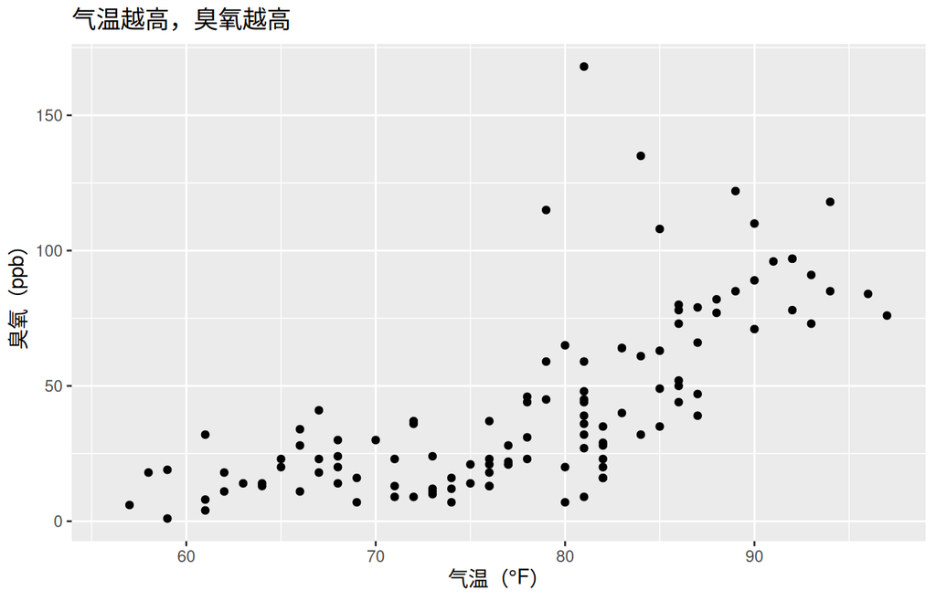

```r
ggplot(airquality, aes(x = Temp, y = Ozone)) +
    geom_point() +
    labs(x = "气温（°F）", y = "臭氧（ppb）",
         title = "气温越高，臭氧越高")
```

把 `geom_point()` 换成 `geom_smooth()`、`geom_bin2d()`，数据与映射一个字都不用改：

[output not shown]

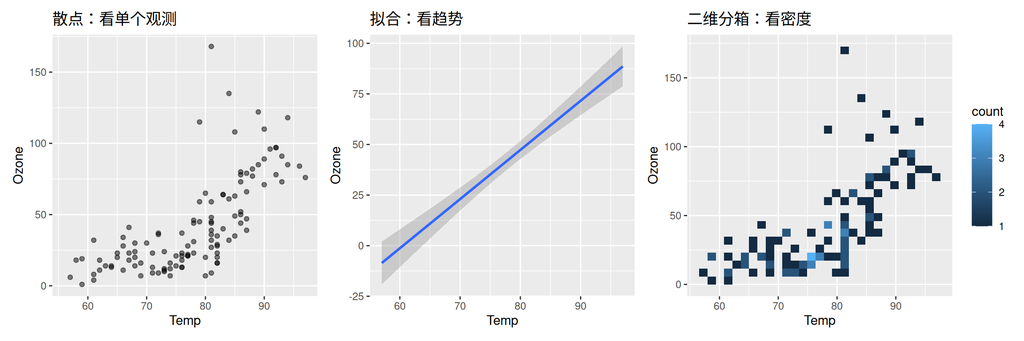

```r
p1 <- ggplot(airquality, aes(Temp, Ozone)) + geom_point(alpha = .5) + ggtitle("散点：看单个观测")
p2 <- ggplot(airquality, aes(Temp, Ozone)) + geom_smooth(method = "lm") + ggtitle("拟合：看趋势")
p3 <- ggplot(airquality, aes(Temp, Ozone)) + geom_bin2d() + ggtitle("二维分箱：看密度")

aplot::plot_list(p1, p2, p3, ncol = 3)
```

**WarningMonth 是整数**

在 `aes(color = Month)` 里直接用它上色，ggplot2 给出的是一条**连续的色带**，而不是五个离散的分组：

```
#> Warning: Removed 37 rows containing missing values or values outside the scale range
#> (`geom_point()`).
#> Removed 37 rows containing missing values or values outside the scale range
#> (`geom_point()`).
```

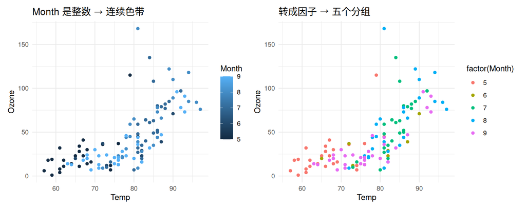

```r
p_bad <- ggplot(airquality, aes(Temp, Ozone, color = Month)) +
    geom_point() + ggtitle("Month 是整数 → 连续色带") + theme_minimal()
p_good <- ggplot(airquality, aes(Temp, Ozone, color = factor(Month))) +
    geom_point() + ggtitle("转成因子 → 五个分组") + theme_minimal()

aplot::plot_list(p_bad, p_good, ncol = 2)
```

两张图的数据完全一样，**只有颜色那一列的类型不同**。类型是数据的一部分。

> 另一个容易搞混的点：**映射**（写在 `aes()` 里，跟着数据变化）和**写死一个值**（写在 `aes()` 外面）不是一回事。`aes(color = "blue")` 造出一个叫 `blue` 的分组，`color = "blue"` 把颜色设成蓝色。

**Tip练习 4**

1. 把 `geom_point()` 换成 `geom_jitter(width = .5, height = 5)`，说明它解决了什么问题。
2. 用 `aes(size = Wind)` 再加一个通道。同时映射 x、y、color、size 四个变量时，图还能读吗？
3. 故意写一次 `aes(color = "blue")`，看看图例里出现了什么，再改成 `color = "blue"`。
4. 用 `scale_color_viridis_d()` 换一套配色，说明”标度”这一层在做什么。

## 5 四类常用图

第 2 讲 Part 05 挑了四类出镜率最高的图。每一类都在同一份数据上画一次，并且都留一个”该看什么”。

### 5.1 分布图：分组分布 + 原始点

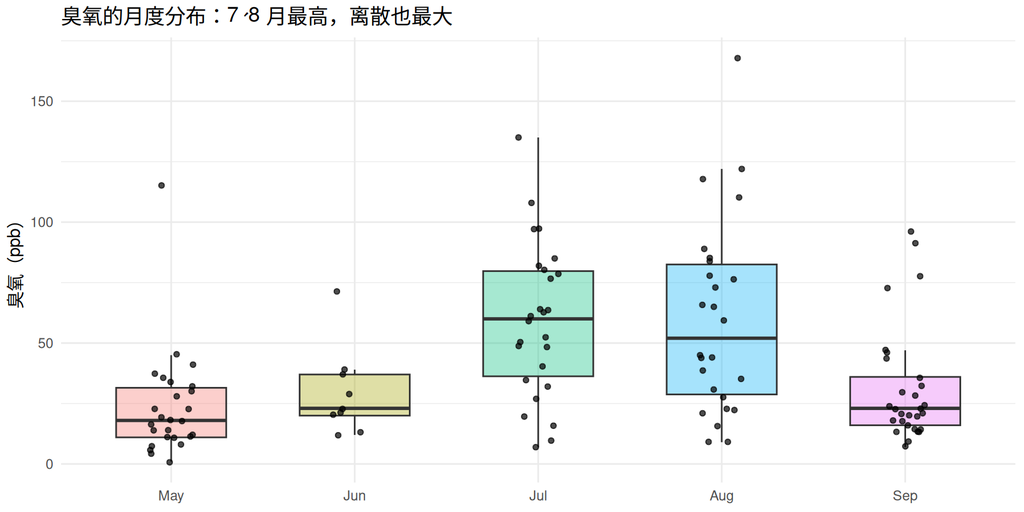

```r
airquality |>
    mutate(month_name = factor(month.abb[Month], levels = month.abb[5:9])) |>
    ggplot(aes(month_name, Ozone)) +
    geom_boxplot(aes(fill = month_name), alpha = .35, width = .6, outlier.shape = NA) +
    geom_jitter(width = .12, size = 1.3, alpha = .7) +
    labs(x = NULL, y = "臭氧（ppb）", fill = "月份",
         title = "臭氧的月度分布：7、8 月最高，离散也最大") +
    theme_minimal() +
    theme(legend.position = "none")
```

**箱线图只画了五个数，原始点把剩下的信息补回来**——7 月的中位数高，同时也夹着几个很低的日子，只画箱子看不到这些。

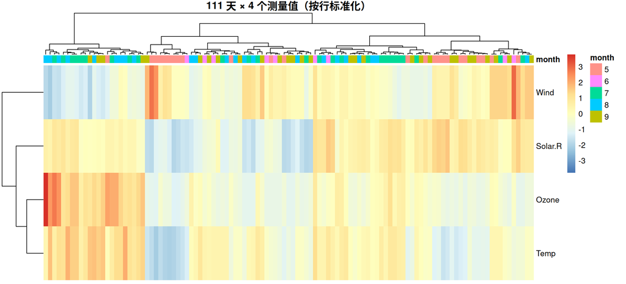

```r
mat <- as.matrix(airquality[, c("Ozone", "Solar.R", "Wind", "Temp")])
rownames(mat) <- paste0(airquality$Month, "-", airquality$Day)

# 热图要求没有缺失，月份单独做成注释条
keep <- complete.cases(mat)
mat_c <- mat[keep, ]
anno_col <- data.frame(month = factor(airquality$Month[keep]))
rownames(anno_col) <- colnames(t(mat_c))   # 注释表的行名必须和矩阵的列名对上

pheatmap(t(mat_c),
         annotation_col = anno_col,
         scale = "row",
         show_colnames = FALSE,
         clustering_method = "ward.D2",
         main = "111 天 × 4 个测量值（按行标准化）")
```

**Warning热图的三个要点**

1. **`scale = "row"` 改变的是数值**：它把每一行标准化成 z 分数，颜色表示”相对这一行自己”的高低。`scale` 选 `"none"`、`"row"`、`"column"` 得到三张不同的图，报告里写清用的是哪一种。
2. **行序（列序）来自聚类**：图上相邻的两行是聚类排在一起的。把 `cluster_rows = FALSE` 打开再画一次，可以看到完全不同的排列。
3. **注释条要和矩阵对齐**：`annotation_col` 的每一行对应矩阵的一列，行名必须与列名一致（上面那句 `rownames(anno_col) <- ...` 就是干这个的）。对不上时 `pheatmap()` 抛出一个和注释颜色有关的费解报错——**遇到看不懂的报错，先检查两个对象的维度与名称**。

### 5.3 PCA：把四个变量压到两个轴上

第 2 讲那页问的是”处理效应还是供体效应，谁更强”；这里的问题形状一样——**这四个测量值背后主要是几件事？**

```r
pca <- prcomp(mat_c, scale. = TRUE)
var_pct <- round(100 * pca$sdev^2 / sum(pca$sdev^2), 1)
var_pct
```

```
#> [1] 59.0 22.4 11.9  6.7
```

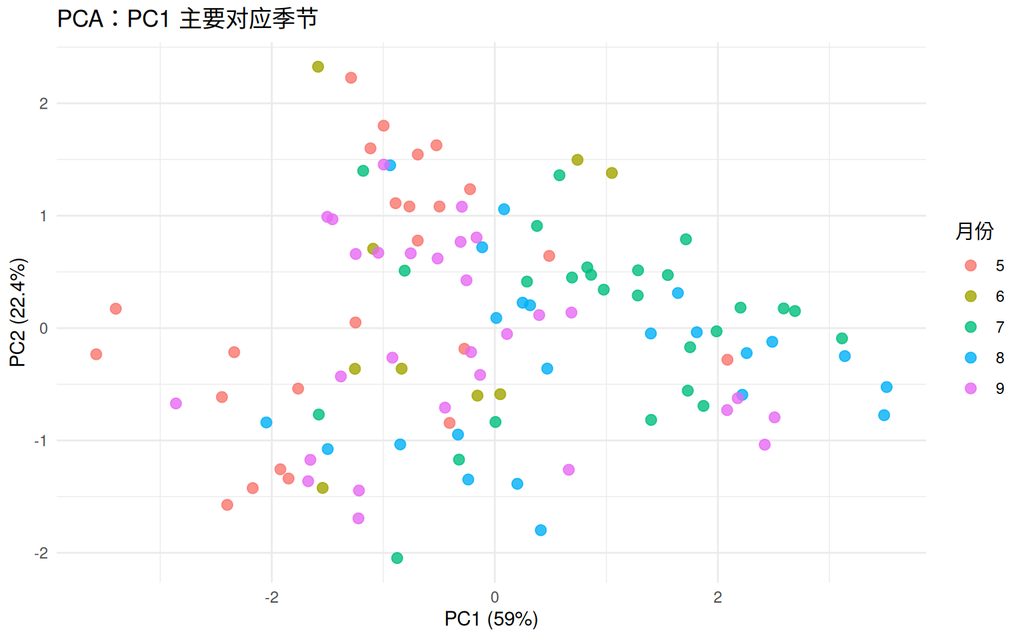

```r
pca_df <- data.frame(pca$x[, 1:2],
                     month = factor(airquality$Month[keep]))
ggplot(pca_df, aes(PC1, PC2, color = month)) +
    geom_point(size = 2.5, alpha = .8) +
    labs(x = paste0("PC1 (", var_pct[1], "%)"),
         y = paste0("PC2 (", var_pct[2], "%)"),
         color = "月份",
         title = "PCA：PC1 主要对应季节") +
    theme_minimal()
```

PC1 单独解释了 **59.0%** 的变异，PC2 解释 22.4%。看载荷与相关系数就知道 PC1 是什么：

```r
round(pca$rotation[, 1:2], 2)
```

```
#>           PC1   PC2
#> Ozone    0.59 -0.06
#> Solar.R  0.32  0.90
#> Wind    -0.50  0.43
#> Temp     0.55 -0.06
```

```r
round(cor(mat_c), 2)
```

```
#>         Ozone Solar.R  Wind  Temp
#> Ozone    1.00    0.35 -0.61  0.70
#> Solar.R  0.35    1.00 -0.13  0.29
#> Wind    -0.61   -0.13  1.00 -0.50
#> Temp     0.70    0.29 -0.50  1.00
```

温度与臭氧正相关（0.70）、风速与臭氧负相关（−0.61）——PC1 正是”热、静、臭氧高”这一组同步变化。**主成分本身没有含义，能解释它的是载荷与相关矩阵**。

**Tip练习 5**

1. 用 `scale. = FALSE` 再跑一次 PCA，方差解释比例变成多少？为什么会变这么多？
2. 把上色变量换成 `factor(cut(Temp, 3))`，PCA 上的结构还清楚吗？
3. 用 `pheatmap(cor(mat_c))` 画相关矩阵热图，说明它和 PCA 各回答什么问题。
4. 在 5.1 的图上把 `fill` 换成 `Temp > 80`，比较两种分组的差别。

### 5.4 组合图：让两个面板共用一个轴

第 2 讲 Part 06 讲”组合图：复杂度在另一个层次”。最常见的组合是**主图 + 边缘分布**：主图看两个变量的关系，边缘图看其中一个变量自己的分布。难点从来不是”拼”，而是**两个面板必须共享同一个坐标轴**。

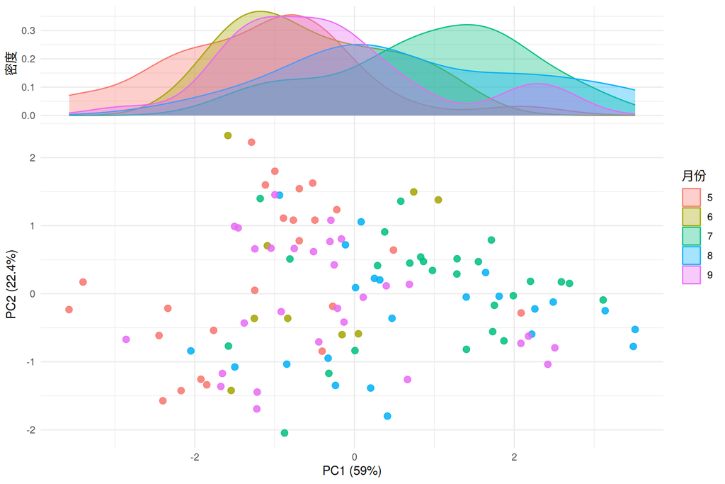

```r
main <- ggplot(pca_df, aes(PC1, PC2, color = month)) +
    geom_point(size = 2.5, alpha = .85) +
    labs(color = "月份", x = paste0("PC1 (", var_pct[1], "%)"),
         y = paste0("PC2 (", var_pct[2], "%)")) +
    theme_minimal() + theme(legend.position = "none")

top <- ggplot(pca_df, aes(PC1, fill = month, color = month)) +
    geom_density(alpha = .35) +
    labs(fill = "月份", color = "月份", x = NULL, y = "密度") +
    theme_minimal() +
    theme(axis.text.x = element_blank(), axis.title.x = element_blank())

insert_top(main, top, height = .35)
```

`insert_top()` **自动把两个面板的横轴对齐**：边缘密度图的横轴与主图严格共享 PC1 的取值范围，眼睛可以直接上下对照。

**Warning对齐的判据**

如果换成 `patchwork` 或 `plot_grid` 各自独立地拼，两个面板各用各的坐标范围，看起来”差不多”但**同一个峰的位置对不上**。判断方法：找主图上最左（或最右）的那个点，看它在边缘密度图里对应的位置是否一致。

**Tip练习 6**

1. 把 `insert_top()` 换成 `patchwork::wrap_plots(main, top, ncol = 1)`，找主图上最左的点，比较两个面板里它的横坐标位置，说明差别。
2. 用 `ggsave()` 把上面这张组合图存成 8 × 6 英寸、300 dpi 的 PNG，检查文件大小。
3. 给 5.1 的图加 `facet_wrap(~ month_name)`，说明分面解决了什么问题、又带来什么新问题。
4. **换一份数据、同一套语法**：用 ggplot2 自带的 `mpg`，把 `hwy` 按 `class` 分组画一箱一点图，再加 `facet_wrap(~ year)`。只需改数据与列名。

## 6 交付要求

把上面的练习整理成一份 Quarto 报告：

1. **代码块可见**，每个练习的代码单独一块；
2. **每个练习后面写结论**，一到两句，写”我算出了什么、怎么判断它对不对”；
3. **至少两张图在正文里被讨论过**：说清图上哪一部分支持你的结论；
4. 最后一段 **“我改了哪里”**：列出你改过的参数（`scale`、`cluster_rows`、`geom_*`、主题、阈值），以及改动前后图或数字的变化——**结论要能追溯到参数**。

```r
# 一份报告骨架：
# quarto render report.qmd
#
# report.qmd 的 YAML：
# ---
# title: "R 语言与数据可视化 · 上机报告"
# author: "你的名字"
# format: html
# ---
```

## 7 进阶练习：K-means

前面的图都在回答”哪些观测彼此接近”。K-means 换一个问法：**不用任何已知分组，能不能让数据自己站队？** 这正是第 5 讲单细胞聚类的思想雏形——那边换成了 Louvain 社区发现，但”先定分组数、再看结果稳不稳”的麻烦是一样的。

1. 跑通 `kmeans(iris[, -5], centers = 3)`，和真实物种做交叉表，说明它错在哪一朵花上；
2. 用肘部法则选 `k`，画出组内平方和随 `k` 的变化曲线；
3. 把同一批数据先用 PCA 降到 2 维再聚类，比较结果；
4. 用 `set.seed()` 固定随机种子，重跑三次，说明结果的稳定性。

**NoteK-means 与层次聚类**